# Homework6

Colleen Yancey

February 25, 2018

#### 1. Set up a new `.Rmd` file for this exercise. Copy and paste the code below into different code chunks, and then read the text and run the code chunks one at a time to see what they do. You probably won’t understand everything in the code, but this is a good start for seeing some realistic uses of ggplot. We will cover most of these details in the next few weeks.

```r
library(ggplot2) # for graphics
library(MASS) # for maximum likelihood estimation
```

To illustrate, we will generate some fake data here:

```r
#z <- rnorm(n=3000,mean=0.2)
#z <- data.frame(1:3000,z)
#names(z) <- list("ID","myVar")
```

#### 2. Once the code is in and runs, try reading in your own .csv file into a data frame with this code chunk:

The data I will be using is part of my honors thesis. Specifically, it is the Hyphae bag analysis that I am currently working on. The data set is not yet complete but I think it is large enough to do this problem set. The data will inform me of hyphal growth rates over the course of one growing season in the ice storm plots.

#### 3. Once your data are in, go ahead and comment out the “fake data” that are simulated in the chunk below. At that point, if you compile the entire file, it should run all of the code on your own data. Be sure to add comments to the code and commentary to the .Rmd file so that you can go back to it later and understand and use the code in your work.

```r
z <- read.table("ECMScores.csv",header=TRUE,sep=",", stringsAsFactors=FALSE)
str(z)
```

```
## 'data.frame':    30 obs. of  3 variables:
##  $ ID         : int  1 2 3 4 5 6 7 8 9 10 ...
##  $ ECM.tips.cm: num  1.05 1.15 1.05 1.46 1.36 ...
##  $ Treatment  : chr  "mod x 2" "mod x 2" "mod x 2" "moderate" ...
```

```r
summary(z)
```

```
##        ID         ECM.tips.cm      Treatment
##  Min.   : 1.00   Min.   :0.7431   Length:30
##  1st Qu.: 8.25   1st Qu.:1.0779   Class :character
##  Median :15.50   Median :1.3184   Mode  :character
##  Mean   :15.50   Mean   :1.3375
##  3rd Qu.:22.75   3rd Qu.:1.5137
##  Max.   :30.00   Max.   :2.1870
```

### Histogram Plot

Plot a histogram of the data, using a modification of the code from lecture. Here we are switching from qplot to ggplot for more graphics options. We are also rescaling the y axis of the histogram from counts to density, so that the area under the histogram equals 1.0.

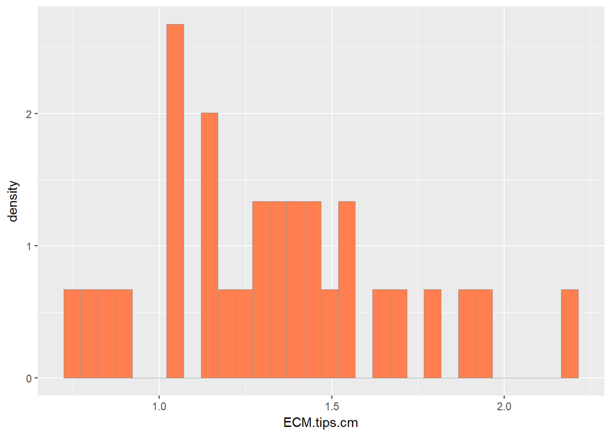

```r
# this will make a histogram
p1 <- ggplot(data=z, aes(x=ECM.tips.cm, y=..density..)) +
  geom_histogram(color="grey60",fill="coral",size=0.2)
print(p1)
```

### Emprical Density Curve

Now modify the code to add in a kernel density plot of the data. This is an empirical curve that is fitted to the data. It does not assume any particular probability distribution, but it smooths out the shape of the histogram:

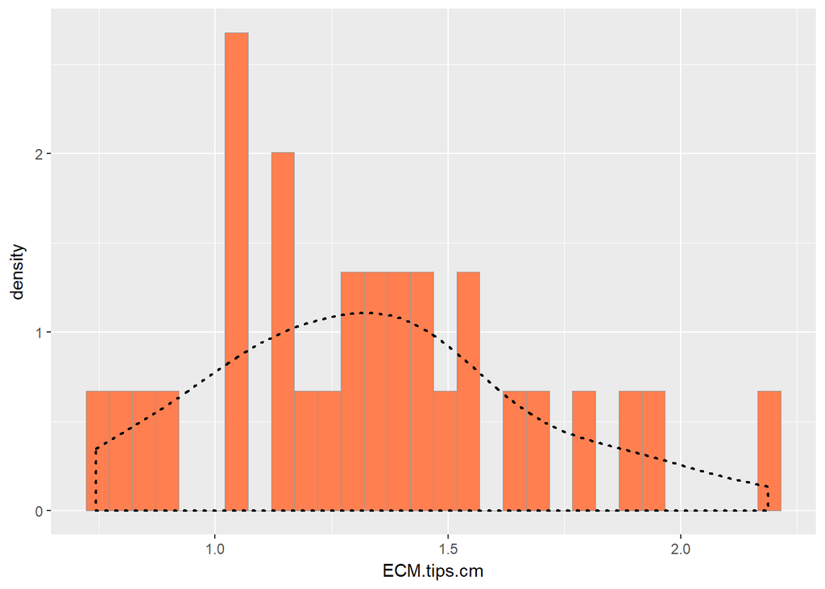

```r
# this will make the data fit to a smoother curve
p1 <-  p1 +  geom_density(linetype="dotted",size=0.75)
print(p1)
```

### Find the Parameters of rnorm

```r
normPars <- fitdistr(z$ECM.tips.cm,"normal")
print(normPars)
```

```
##       mean          sd
##   1.33754956   0.34484626
##  (0.06296003) (0.04451946)
```

The above function returns the mean and standard deviation of the data set.

```r
str(normPars)
```

```
## List of 5
##  $ estimate: Named num [1:2] 1.338 0.345
##   ..- attr(*, "names")= chr [1:2] "mean" "sd"
##  $ sd      : Named num [1:2] 0.063 0.0445
##   ..- attr(*, "names")= chr [1:2] "mean" "sd"
##  $ vcov    : num [1:2, 1:2] 0.00396 0 0 0.00198
##   ..- attr(*, "dimnames")=List of 2
##   .. ..$ : chr [1:2] "mean" "sd"
##   .. ..$ : chr [1:2] "mean" "sd"
##  $ n       : int 30
##  $ loglik  : num -10.6
##  - attr(*, "class")= chr "fitdistr"
```

```r
print(normPars)
```

```
##       mean          sd
##   1.33754956   0.34484626
##  (0.06296003) (0.04451946)
```

This function spits out the general structure and information of your data set.

```r
normPars$estimate["mean"]
```

```
##    mean
## 1.33755
```

The above function returns the mean of the data set.

### Plot Normal Probability Density

Now let’s call the dnorm function inside ggplot’s stat_function to generate the probability density for the normal distribution. Read about stat_function in the help system to see how you can use this to add a smooth function to any ggplot. Note that we first get the maximum likelihood parameters for a normal distribution fitted to thse data by calling fitdistr. Then we pass those parameters (meanML and sdML to stat_function:

```r
meanML <- normPars$estimate["mean"]
sdML <- normPars$estimate["sd"]

xval <- seq(0,max(z$ECM.tips.cm),len=length(z$ECM.tips.cm))

 stat <- stat_function(aes(x = xval, y = ..y..), fun = dnorm, colour="red", n = length(z$Height), args = list(mean = meanML, sd = sdML))
 p1 + stat
```

[figure not shown]

###Plot Exponential Curve

```r
expoPars <- fitdistr(z$ECM.tips.cm,"exponential")
rateML <- expoPars$estimate["rate"]

stat2 <- stat_function(aes(x = xval, y = ..y..), fun = dexp, colour="blue", n = length(z$ECM.tips.cm), args = list(rate=rateML))
 p1 + stat + stat2
```

[output not shown]

###Adding a uniform probability Curve Dont use `fitdistr` for this!

```r
stat3 <- stat_function(aes(x = xval, y = ..y..), fun = dunif, colour="darkgreen", n = length(z$myVar), args = list(min=min(z$myVar), max=max(z$myVar)))
 p1 + stat + stat2 + stat3
```

[output not shown]

### Plot Gamma Probability

```r
gammaPars <- fitdistr(z$ECM.tips.cm,"gamma")
shapeML <- gammaPars$estimate["shape"]
rateML <- gammaPars$estimate["rate"]

stat4 <- stat_function(aes(x = xval, y = ..y..), fun = dgamma, colour="goldenrod", n = length(z$Height), args = list(shape=shapeML, rate=rateML))
 p1 + stat + stat2 + stat3 + stat4
```

[output not shown]

### Adding the beta Probability Curve

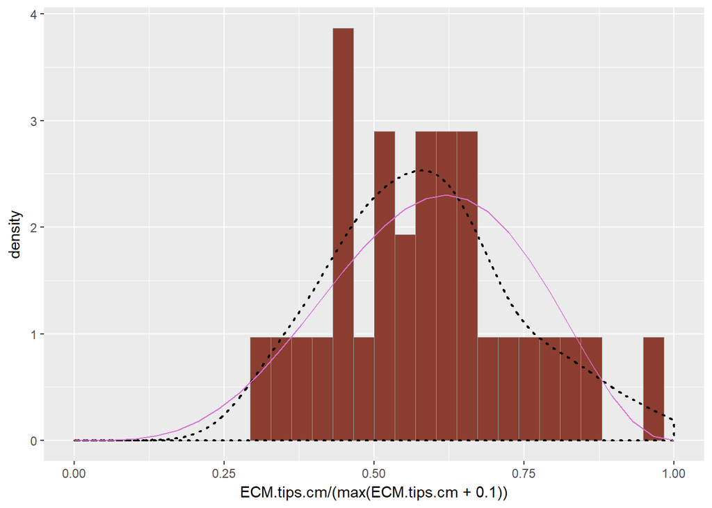

```r
pSpecial <- ggplot(data=z, aes(x=ECM.tips.cm/(max(ECM.tips.cm + 0.1)), y=..density..)) +
  geom_histogram(color="grey60",fill="coral4",size=0.2) +
  xlim(c(0,1)) +
  geom_density(size=0.75,linetype="dotted")

betaPars <- fitdistr(x=z$ECM.tips.cm/max(z$ECM.tips.cm + 0.1),start=list(shape1=1,shape2=2),"beta")
shape1ML <- betaPars$estimate["shape1"]
shape2ML <- betaPars$estimate["shape2"]

statSpecial <- stat_function(aes(x = xval, y = ..y..), fun = dbeta, colour="orchid", n = length(z$ECM.tips.cm), args = list(shape1=shape1ML,shape2=shape2ML))
pSpecial + statSpecial
```

####Which Graph looks better?

```r
normPars$loglik
```

```
## [1] -10.62846
```

```r
gammaPars$loglik
```

```
## [1] -9.97724
```

```r
expoPars$loglik
```

```
## [1] -38.72518
```

A Gamma distribution appears to fit my data the best.

### Determining Maximum Likelihood Parameters

```r
gammaPars <- fitdistr(z$ECM.tips.cm,"gamma")
print(gammaPars)
```

```
##      shape       rate
##   15.018399   11.228293
##  ( 3.835407) ( 2.915869)
```

### Create a Fake Data Set to run on Function

```r
x <- rgamma(n=30,shape=1.3,scale=1/.204)
x <- data.frame(1:30,x)
names(x) <- list("GroupID","ECM.tips.cm")
x <- x[x$ECM.tips.cm>0,]
str(x)
```

```
## 'data.frame':    30 obs. of  2 variables:
##  $ GroupID    : int  1 2 3 4 5 6 7 8 9 10 ...
##  $ ECM.tips.cm: num  8.15 0.26 2.39 7.22 5.71 ...
```

#### Making a Histogram for Fake Data Set

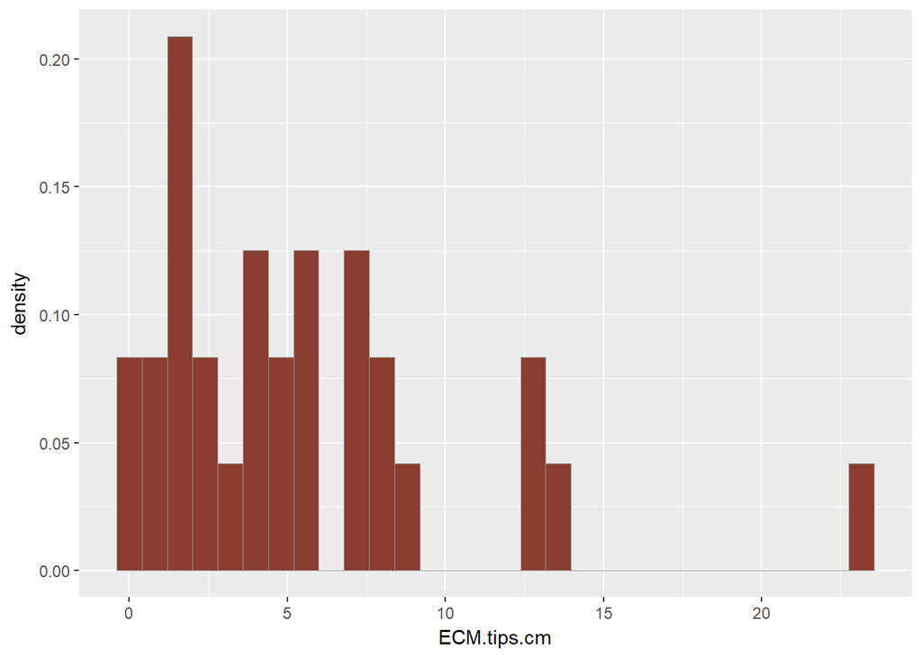

```r
p1 <- ggplot(data=x, aes(x=ECM.tips.cm, y=..density..)) +
  geom_histogram(color="grey60",fill="coral4",size=0.2)
print(p1)
```

###Gamma Distribution for Fake Data

```r
gammaPars <- fitdistr(x$ECM.tips.cm,"gamma")
shapeML <- gammaPars$estimate["shape"]
rateML <- gammaPars$estimate["rate"]

stat4 <- stat_function(aes(x = xval, y = ..y..), fun = dgamma, colour="goldenrod", n = length(x$Height), args = list(shape=shapeML, rate=rateML))
 p1 + stat4
```

[figure not shown]

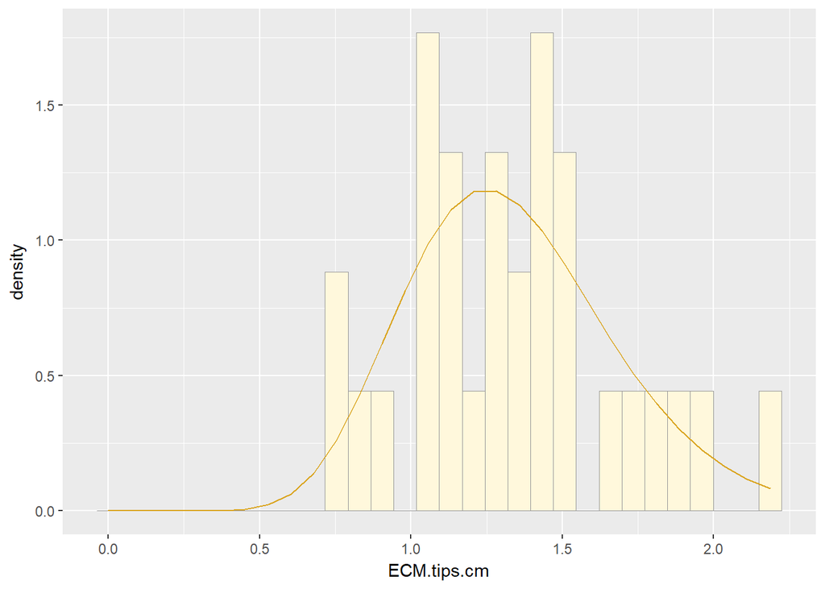

```r
z <- read.table("ECMScores.csv",header=TRUE,sep=",", stringsAsFactors=FALSE)

p1 <- ggplot(data=z, aes(x=ECM.tips.cm, y=..density..)) +
  geom_histogram(color="grey60",fill="cornsilk",size=0.2)


gammaPars <- fitdistr(z$ECM.tips.cm,"gamma")
shapeML <- gammaPars$estimate["shape"]
rateML <- gammaPars$estimate["rate"]

stat4 <- stat_function(aes(x = xval, y = ..y..), fun = dgamma, colour="goldenrod", n = length(z$ECM.tips.cm), args = list(shape=shapeML, rate=rateML))
 p1 + stat4
```